[figure not shown]

# Lecture 33: Least Squares

Associated Textbook Sections: [15.3, 15.4](https://ccsf-math-108.github.io/textbook/chapters/15/3/Method_of_Least_Squares.html)

## Outline

- Least Squares
- Numerical Optimization
- Nonlinear Regression

## Set Up the Notebook

```python
from datascience import *
import numpy as np
%matplotlib inline
import matplotlib.pyplot as plt
plt.style.use('fivethirtyeight')

# Some functions for plotting. You don't have to understand how any
# of the functions in this cell work, since they use things we
# haven't learned about in this course.

def resize_window(lim=3.5):
    plt.xlim(-lim, lim)
    plt.ylim(-lim, lim)

def draw_line(slope=0, intercept=0, x=make_array(-4, 4), color='r'):
    y = x*slope + intercept
    plt.plot(x, y, color=color)

def draw_vertical_line(x_position, color='black'):
    x = make_array(x_position, x_position)
    y = make_array(-4, 4)
    plt.plot(x, y, color=color)

def make_correlated_data(r):
    x = np.random.normal(0, 1, 1000)
    z = np.random.normal(0, 1, 1000)
    y = r*x + (np.sqrt(1-r**2))*z
    return x, y

def r_table(r):
    """
    Generate a table of 1000 x,y data points in standard units
    whose correlation is approximately equal to r
    """
    np.random.seed(8)
    x, y = make_correlated_data(r)
    return Table().with_columns('x', x, 'y', y)

def standard_units(x):
    """Converts an array x to standard units"""
    return (x - np.mean(x)) / np.std(x)

def correlation(t, x, y):
    x_su = standard_units(t.column(x))
    y_su = standard_units(t.column(y))
    return np.mean(x_su * y_su)

def slope(t, x, y):
    return correlation(t, x, y) * np.std(t.column(y)) / np.std(t.column(x))

def intercept(t, x, y):
    return np.mean(t.column(y)) - slope(t, x, y) * np.mean(t.column(x))
```

## Least Squares

### Interpreting a Relationship

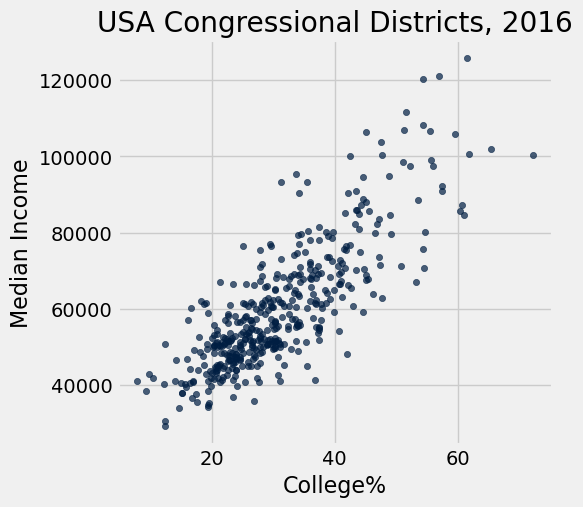

```python
demographics = Table().read_table('district_demographics2016.csv')
demographics.scatter('College%', 'Median Income')
plt.title('USA Congressional Districts, 2016')
plt.show()
```

```python
demographics
```

| State | District | Median Income | College% |
| --- | --- | --- | --- |
| Alabama | Congressional District 1 (115th Congress), Alabama | 47083 | 24 |
| Alabama | Congressional District 2 (115th Congress), Alabama | 42035 | 21.8 |
| Alabama | Congressional District 3 (115th Congress), Alabama | 46544 | 22.8 |
| Alabama | Congressional District 4 (115th Congress), Alabama | 41110 | 17 |
| Alabama | Congressional District 5 (115th Congress), Alabama | 51690 | 30.3 |
| Alabama | Congressional District 6 (115th Congress), Alabama | 61413 | 36.7 |
| Alabama | Congressional District 7 (115th Congress), Alabama | 34664 | 19.4 |
| Alaska | Congressional District (at Large) (115th Congress), Alaska | 76440 | 29.6 |
| Arizona | Congressional District 1 (115th Congress), Arizona | 50537 | 24.5 |
| Arizona | Congressional District 2 (115th Congress), Arizona | 49072 | 34 |

... (425 rows omitted)

Based only on the above graph, which must be true?

1. Going to college causes people to get higher incomes.
2. For any district, having more college-educated people live there causes median incomes to rise.
3. For any district, having a higher median income causes more college-educated people to move there.

### Error in Estimation

- `error = actual value - estimate`
- Typically, some errors are positive and some negative
- A way to measure the rough size of the errors:
  - square the errors to eliminate cancellation
  - take the mean of the squared errors
  - take the square root to fix the units
- This is called the root mean square error (rmse)

### Demo: Regression line vs other lines

- Use the following functions with the 2016 demographics data to explore the relationship between Median Income and College completion within the US voting districts.
- Determine the slope and intercept for the linear regression line to predict median income values from `"College%"` values.
- Analyze the errors formed when applying the predictions on the provided `"College%"` data values.

```python
def demographics_errors(slope, intercept):
    # Use four convenient points from the original data
    sample = [[14.7, 33995], [19.1, 61454], [50.7, 71183], [59.5, 105918]]
    demographics.scatter('College%', 'Median Income', alpha=0.5)
    xlims = make_array(5, 75)
    # Plot a line with the slope and intercept you specified:
    plt.plot(xlims, slope * xlims + intercept, lw=4)
    # Plot red lines from each of the four points to the line
    for x, y in sample:
        plt.plot([x, x], [y, slope * x + intercept], color='r', lw=4)
```

```python
def fitted_values(t, x, y):
    """Return an array of the regressions estimates at all the x values"""
    a = slope(t, x, y)
    b = intercept(t, x, y)
    return a*t.column(x) + b
```

```python
demographics = demographics.drop(
    'State', 'District')
demographics.show(5)
```

| Median Income | College% |
| --- | --- |
| 47083 | 24 |
| 42035 | 21.8 |
| 46544 | 22.8 |
| 41110 | 17 |
| 51690 | 30.3 |

... (430 rows omitted)

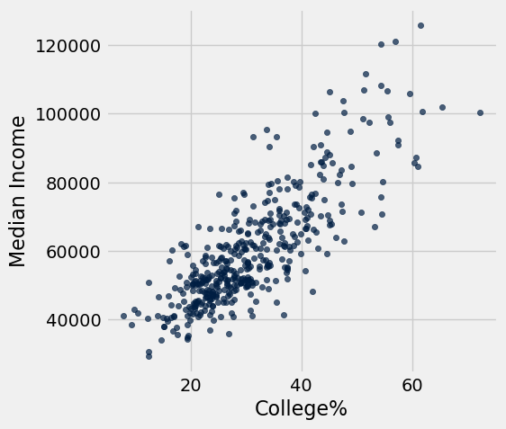

```python
demographics.scatter('College%', 'Median Income')
```

```python
correlation(demographics, 'College%', 'Median Income')
```

```
0.81846485171413352
```

```python
regression_slope = slope(demographics, 'College%', 'Median Income')
regression_intercept = intercept(demographics, 'College%', 'Median Income')
print(f'The best fit line has a slop of {regression_slope:0.4f} and an intercept of {regression_intercept:0.4f}.')
```

```
The best fit line has a slop of 1270.7017 and an intercept of 20802.5778.
```

```python
predicted = fitted_values(demographics, 'College%', 'Median Income')
```

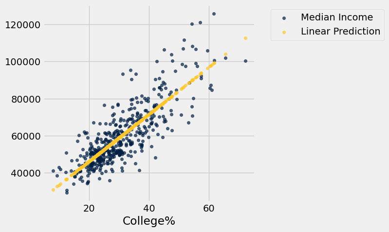

```python
demographics = demographics.with_column(
    'Linear Prediction', predicted)
demographics.scatter('College%')
```

```python
actual = demographics.column('Median Income')
errors = actual - predicted
```

```python
demographics.with_column('Error', errors)
```

| Median Income | College% | Linear Prediction | Error |
| --- | --- | --- | --- |
| 47083 | 24 | 51299.4 | -4216.42 |
| 42035 | 21.8 | 48503.9 | -6468.87 |
| 46544 | 22.8 | 49774.6 | -3230.58 |
| 41110 | 17 | 42404.5 | -1294.51 |
| 51690 | 30.3 | 59304.8 | -7614.84 |
| 61413 | 36.7 | 67437.3 | -6024.33 |
| 34664 | 19.4 | 45454.2 | -10790.2 |
| 76440 | 29.6 | 58415.3 | 18024.7 |
| 50537 | 24.5 | 51934.8 | -1397.77 |
| 49072 | 34 | 64006.4 | -14934.4 |

... (425 rows omitted)

```python
np.mean(errors)
```

```
6.3560089503211536e-13
```

```python
np.mean(errors**2)
```

```
88332095.268617392
```

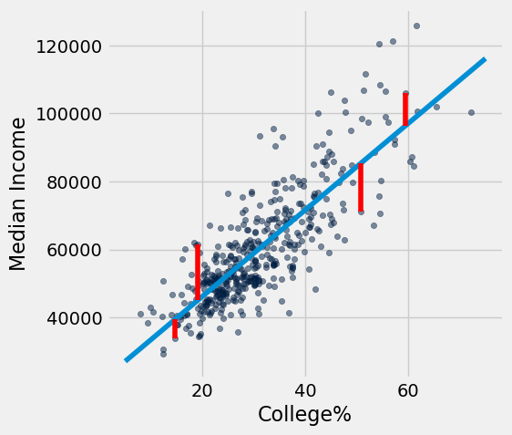

```python
demographics_errors(regression_slope, regression_intercept)
```

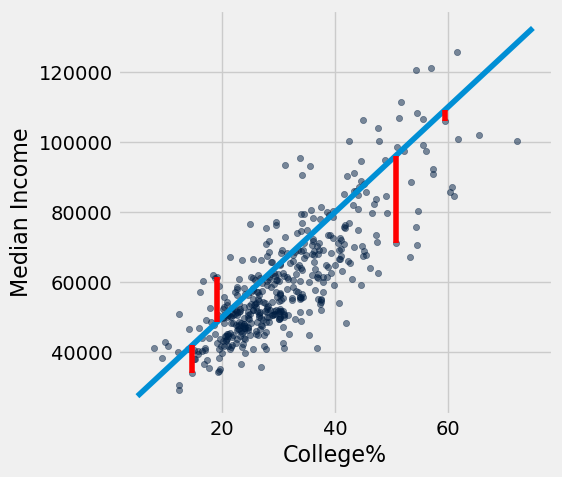

```python
demographics_errors(1500, 20000)
```

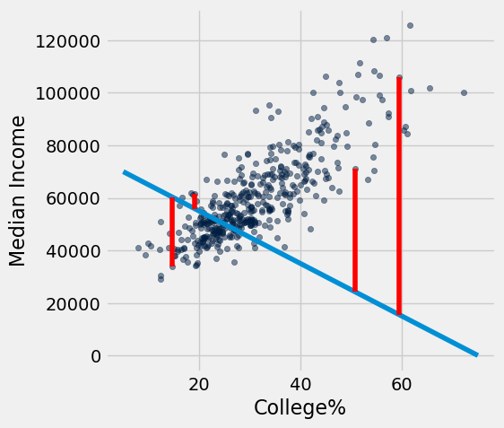

```python
demographics_errors(-1000, 75000)
```

### Least Squares Line

- Minimizes the root mean squared error (rmse) among all lines
- Equivalently, minimizes the mean squared error (mse) among all lines
- Common Names:
  - "Best fit" line
  - Least squares line
  - Regression line

### Demo: Root Mean Square Error

Explore the root mean square error through the demographics relationship.

```python
def show_demographics_rmse(slope, intercept):
    demographics_errors(slope, intercept)
    x = demographics.column('College%')
    y = demographics.column('Median Income')
    prediction = slope * x + intercept
    mse = np.mean((y - prediction) ** 2)
    print("Root mean squared error:", round(mse ** 0.5, 2))
```

```
Root mean squared error: 30247.88
```

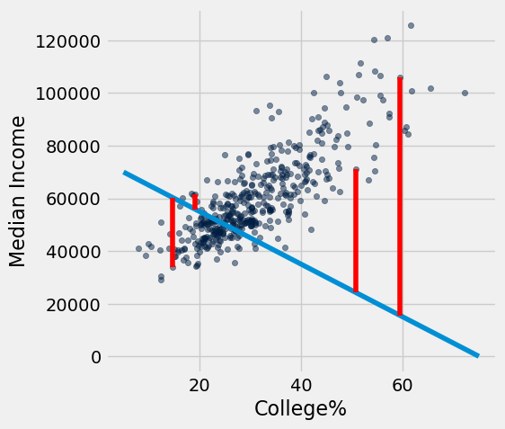

```python
show_demographics_rmse(-1000, 75000)
```

```
Root mean squared error: 11559.09
```

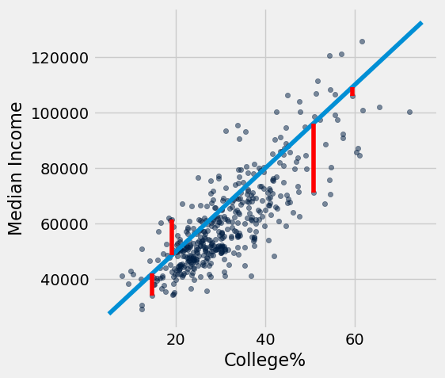

```python
show_demographics_rmse(1500, 20000)
```

```
Root mean squared error: 9398.52
```

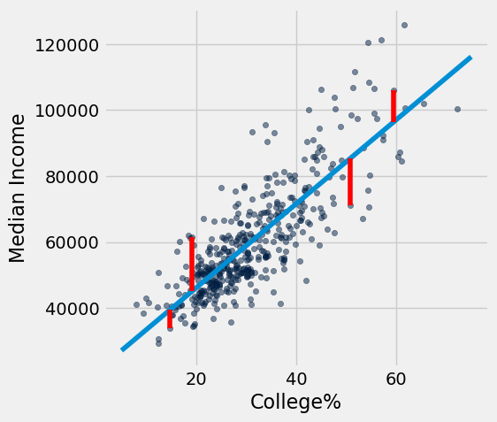

```python
show_demographics_rmse(regression_slope, regression_intercept)
```

## Numerical Optimization

### Numerical Optimization

- Numerical minimization is approximate but effective
- Lots of machine learning uses numerical minimization
- If the function `mse(a, b)` returns the mse of estimation using the line `estimate = ax + b`, then `minimize(mse)` returns array `[slope, intercept]`
- the values are the slope and the intercept of the line that minimizes the mse among all possible lines.

### Demo: Numerical Optimization

Explore the concept of numerical optimization.

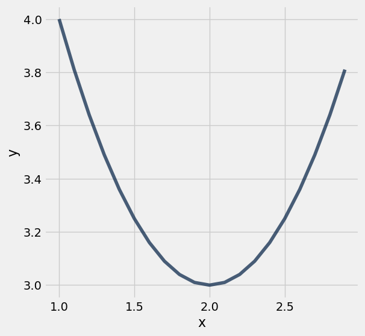

```python
x = np.arange(1, 3, 0.1)
y = (x-2)**2 + 3
Table().with_columns('x', x, 'y', y).plot('x')
```

```python
def f(x):
    return ((x-2)**2) + 3
```

```python
minimize(f)
```

```
1.9999999946252267
```

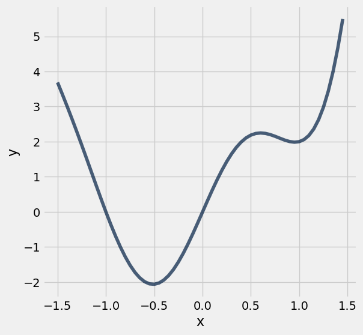

```python
x = np.arange(-1.5, 1.5, 0.05)
y2 = 2 * np.sin(x*np.pi) + x ** 3 + x ** 4
Table().with_columns('x', x, 'y', y2).plot('x')
```

```python
def complicated_function(x):
    return 2 * np.sin(x*np.pi) + x ** 3 + x ** 4
```

```python
minimize(complicated_function)
```

```
-0.5126437620940081
```

### Demo: Minimizing RMSE

Show how minimizing on the demographics rmse produces the same slope and intercept values found above.

```python
def demographics_rmse(any_slope, any_intercept):
    x = demographics.column('College%')
    y = demographics.column('Median Income')
    estimate = any_slope*x + any_intercept
    return (np.mean((y - estimate) ** 2)) ** 0.5
```

```python
demographics_rmse(1500, 20000)
```

```
11559.086490075999
```

```python
demographics_rmse(-1000, 75000)
```

```
30247.883767944502
```

```python
minimize(demographics_rmse)
```

```
array([  1270.70168805,  20802.57933807])
```

```python
make_array(regression_slope, regression_intercept)
```

```
array([  1270.70168946,  20802.57776668])
```

## Nonlinear Regression

### Demo: Trying Linear Regression

```python
shotput = Table.read_table('shotput.csv')
shotput
```

| Weight Lifted | Shot Put Distance |
| --- | --- |
| 37.5 | 6.4 |
| 51.5 | 10.2 |
| 61.3 | 12.4 |
| 61.3 | 13 |
| 63.6 | 13.2 |
| 66.1 | 13 |
| 70 | 12.7 |
| 92.7 | 13.9 |
| 90.5 | 15.5 |
| 90.5 | 15.8 |

... (18 rows omitted)

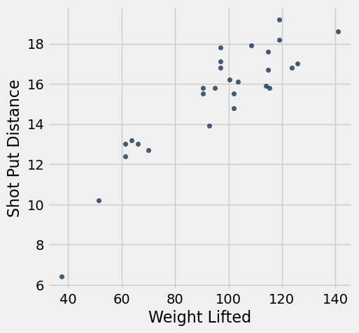

```python
shotput.scatter('Weight Lifted')
```

```python
def shotput_linear_rmse(any_slope, any_intercept):
    x = shotput.column('Weight Lifted')
    y = shotput.column('Shot Put Distance')
    estimate = any_slope*x + any_intercept
    return np.mean((y - estimate) ** 2) ** 0.5
```

```python
best_line = minimize(shotput_linear_rmse)
best_line
```

```
array([ 0.09834382,  5.95962883])
```

```python
weights = shotput.column(0)
```

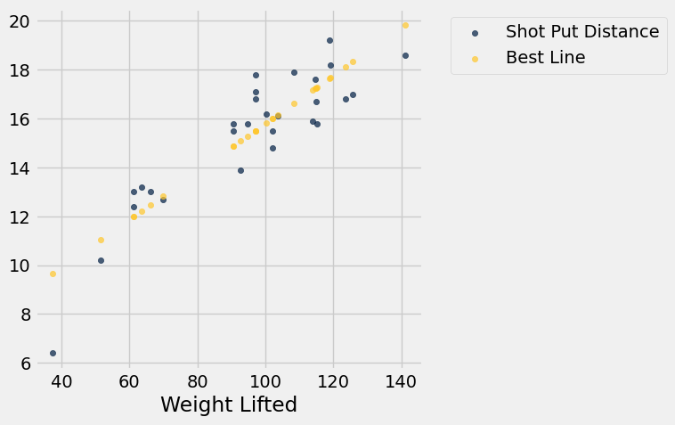

```python
linear_fit = best_line.item(0)*weights + best_line.item(1)

shotput_line = shotput.with_column('Best Line', linear_fit)
shotput_line.scatter('Weight Lifted')
```

```python
rmse_linear = (np.sqrt(np.mean((shotput_line.column('Shot Put Distance') - shotput_line.column('Best Line')) ** 2)))

rmse_linear
```

```
1.2194444845058761
```

### Demo: Nonlinear Regression

Try using a quadratic model instead.

- Quadratic models are nonlinear models.
- The generic structure for a quadratic model is: $$ f(x) ~=~ ax^2 + bx + c $$ for constants $a$, $b$, and $c$.

```python
def shotput_quadratic_rmse(a, b, c):
    x = shotput.column('Weight Lifted')
    y = shotput.column('Shot Put Distance')
    estimate = a*(x**2) + b*x + c # SOLUTION
    return np.mean((y - estimate) ** 2) ** 0.5
```

```python
best_quad = minimize(shotput_quadratic_rmse)
best_quad
```

```
array([ -1.04003731e-03,   2.82706003e-01,  -1.53167618e+00])
```

```python
# x = weight lifted = 100 kg
# Then predicted shot put distance:
a = best_quad.item(0)
b = best_quad.item(1)
c = best_quad.item(2)

prediction_for_100kg = a * (100 ** 2) + b * 100 + c
prediction_for_100kg
```

```
16.338550997580597
```

```python
quad_fit = a * (weights **2) + b * weights + c
```

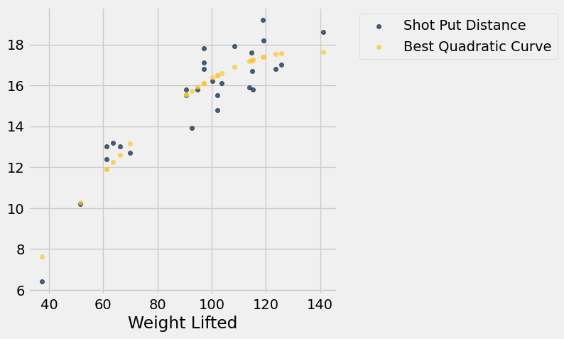

```python
shotput_quad = shotput.with_column('Best Quadratic Curve', quad_fit)
shotput_quad.scatter('Weight Lifted')
```

```python
rmse_quad = (np.sqrt(np.mean((shotput_quad.column('Shot Put Distance') - shotput_quad.column('Best Quadratic Curve')) ** 2)))
rmse_quad
```

```
0.98188452305971619
```

```python
percent_improvement = ((rmse_linear - rmse_quad) / rmse_linear) * 100
print(f'There is a {percent_improvement:.2f}% improvement (reduction) in \
the RMSE using the best quadratic model over the best linear model.')
```

```
There is a 19.48% improvement (reduction) in the RMSE using the best quadratic model over the best linear model.
```

## Attribution

This content is licensed under the Creative Commons Attribution-NonCommercial-ShareAlike 4.0 International License (CC BY-NC-SA 4.0) and derived from the Data 8: The Foundations of Data Science offered by the University of California, Berkeley.